# Markowitz Model - Optimal Allocation

Juan Carlos Martínez-Ovando

jc-mo@tec.mx

Febrero-Junio 2020

# 1 Objetives

- In this note, we shall learn to implement and interpret the optimal allocation problem under Markowitz model perspective, using `R`

# 2 Portfolio allocation problem

## 2.1 Components

Let us recall that the `portfolio allocation problem` for $n$ assets can be addressed as a **decision theory** problem under *uncertainty* using the following components:

1. **Decision space.-** Defined as the collection of possible portfolio allocation strategies, given by the collection of different proportions available to us to distribute the 100% investment capital amont the $n$ assets, i.e.
   $$\mathcal{\Omega} = \left\{(\omega_1,\ldots,\omega_n): \omega_i \geq 0 \text{ and } \sum_{i=1}^{n}\omega_i=1 \right\}.$$

> Note that if $(r_1,\ldots,r_n)$ denote the return values of the $n$ assets at a given time, the **return value of the portfolio** would be defined as
> $$\sum_{i=1}^{n}\omega_i r_i = \boldsymbol{\omega}'\boldsymbol{r}.$$
2. **Uncertainty space.-** In this particular case, since the allocation problem takes place at the begining of time $t$ (a.k.a. towards the end of time $(t-1)$), and the investment takes place along the period $(t-1,t]$, the result of the investment at the end of $t$ is unknown to us at the begining of the same period (begining of $t$ == end of $(t-1)$).

Thus, what best represent our state of uncertainty corresponds to the actual value of the **return performance** for the $n$ assets along $t$, i.e. the uncertainty space would correspond to the collection of all the return results for the $n$ assets during time $t$, i.e.
$$\mathcal{R}_t=\left\{ (r_{1t},\ldots,r_{nt}): r_{it} \in \mathbb{R} \right\},$$
since each one of the assest may or may not have positive returns.

3. **Probability function.-** With the aim of getting a better understanding about the possible outcomes that the $n$ assets may have during time $t$, we make use of the *multivariate Gaussian distribution*. This distribution allow us to understand three key aspects of the possible realization of the $n$ returns:
- Expected return values,
  $$\hat{\mu}_t=(\mu_{1t},\ldots,\mu_{nt}),$$
  where $\mu_{it}=\mathbb{E}(r_{it})$.
- Volatility/risk/dispersion of returns,
  $$\hat{\sigma}^2_t=(\sigma^2_{1t},\ldots,\sigma^2_{nt}),$$
  where $\sigma^2_{it}=var(r_{it})$.
- Comovement/synchronicity/covariance among each pair of return assets,
  $$\hat{\sigma}_{t}=(\sigma_{ijt}),$$
  where $\sigma_{ijt}=cov(r_{it},r_{jt})$.

> The above three characteristics are learned from past data observed before time $t$, i.e. the above characteristics correspond to the point estimates of mean, variance and covariances of the Gaussian distribution using observed data before time $t$.

Thus, we can say that at the begining of time $t$, we can foresee that the possible outcomes of the $n$ return assets can be described as
$$(r_{it},\ldots,r_{nt}) \sim N\left(\hat{\mu}_t,\hat{\Sigma}_t\right),$$
where
$$\hat{\Sigma}_t = \text{estimated covariance matrix for time }t.$$

> This point estimates are the ones that you estimated in `Actividad 1` for this subject.
4. **Preference function.-** According to *Markowtiz approach to the portfolio allocation problem*, we can assess the preference of *uncertain return outcomes*, $\boldsymbol{r}_t=(r_{1t},\ldots,r_{nt})$, for a given *decision/allocation strategy*, $\boldsymbol{\omega}=(\omega_{1t},\ldots,\omega_{nt})$, using the utility function

5. **Decision rule.-** This component close with the specification of the decision theory problem associated with the *portfolio allocation problem*.

> This component is crucial, as it guide us towards the most effective election of the decision variables.

The **decision rule** is demostrated to be **optimal** if we base the election of $(\omega_{1t},\ldots,\omega_{nt})$ with the aim at either

- **Maximizing the expected gain** associated with $U(\boldsymbol{r}_t,\boldsymbol{\omega})$

or

- **Minimizing the expected loss** associated with $U(\boldsymbol{r}_t,\boldsymbol{\omega})$.

> The solution, in this context is referred as **maximizing expected utility** or **minimizing expected loss**.

In the context of the *portfolio allocation problem*, the aforementioned decision rule is typically referred to the **quadratic optimization problem** given by

$$\begin{eqnarray}
\text{min}_{\boldsymbol{\omega}\in\Omega} \boldsymbol{\omega}'\hat{\Sigma}\boldsymbol{\omega} && \\
\text{s.t.} && \boldsymbol{\omega}'\boldsymbol{\mu}_t = \mu^*\\
&& \boldsymbol{\omega}'\boldsymbol{1} = 1,\\
\end{eqnarray}$$
where $\mu^*$ corresponds to a target portfolio return.

> With this approach, we select the *portfolio allocation stratgy* based on *minimizing risk* while *achieving a target expected return* in the portfolio.

## 2.2 Example

### 2.2.1 Data

Revisiting the exmaple of previous sessions, for `Petrobras` and `SP500` series:

```r
library("quantmod")
# Petrobrass series

pbr <- getSymbols("PBR",
                  src = "yahoo",
                  from = "2013-01-01",
                  to = "2017-06-01",
                  auto.assign = FALSE)
```

[output not shown]

```r
summary(pbr)
```

```
##      Index               PBR.Open        PBR.High        PBR.Low
##  Min.   :2013-01-02   Min.   : 2.88   Min.   : 2.97   Min.   : 2.71
##  1st Qu.:2014-02-08   1st Qu.: 7.05   1st Qu.: 7.20   1st Qu.: 6.82
##  Median :2015-03-18   Median :10.26   Median :10.43   Median :10.09
##  Mean   :2015-03-17   Mean   :10.83   Mean   :11.02   Mean   :10.62
##  3rd Qu.:2016-04-23   3rd Qu.:14.63   3rd Qu.:14.84   3rd Qu.:14.40
##  Max.   :2017-05-31   Max.   :20.83   Max.   :20.94   Max.   :20.01
##    PBR.Close        PBR.Volume         PBR.Adjusted
##  Min.   : 2.900   Min.   :  6046400   Min.   : 2.780
##  1st Qu.: 7.005   1st Qu.: 17193900   1st Qu.: 6.716
##  Median :10.230   Median : 24066300   Median : 9.789
##  Mean   :10.814   Mean   : 27530077   Mean   :10.218
##  3rd Qu.:14.615   3rd Qu.: 33655150   3rd Qu.:13.739
##  Max.   :20.650   Max.   :164885500   Max.   :19.798
```

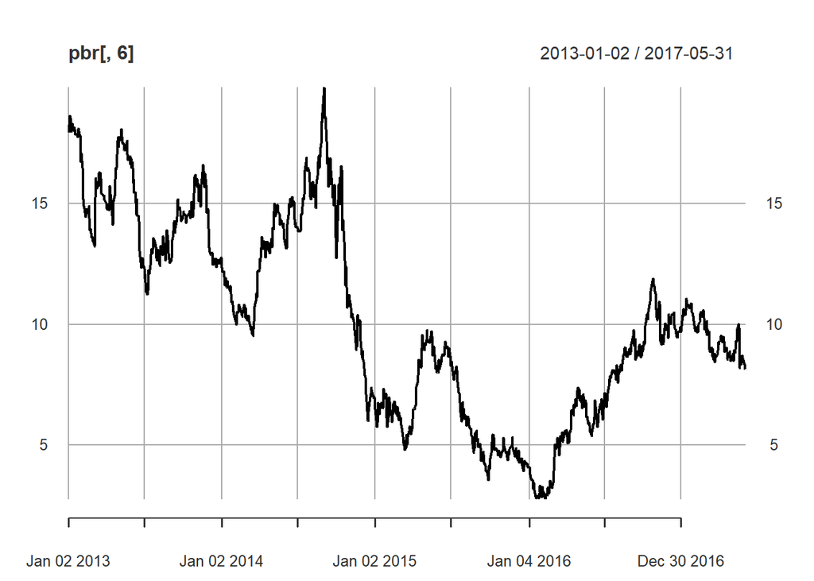

```r
plot(pbr[,6])
```

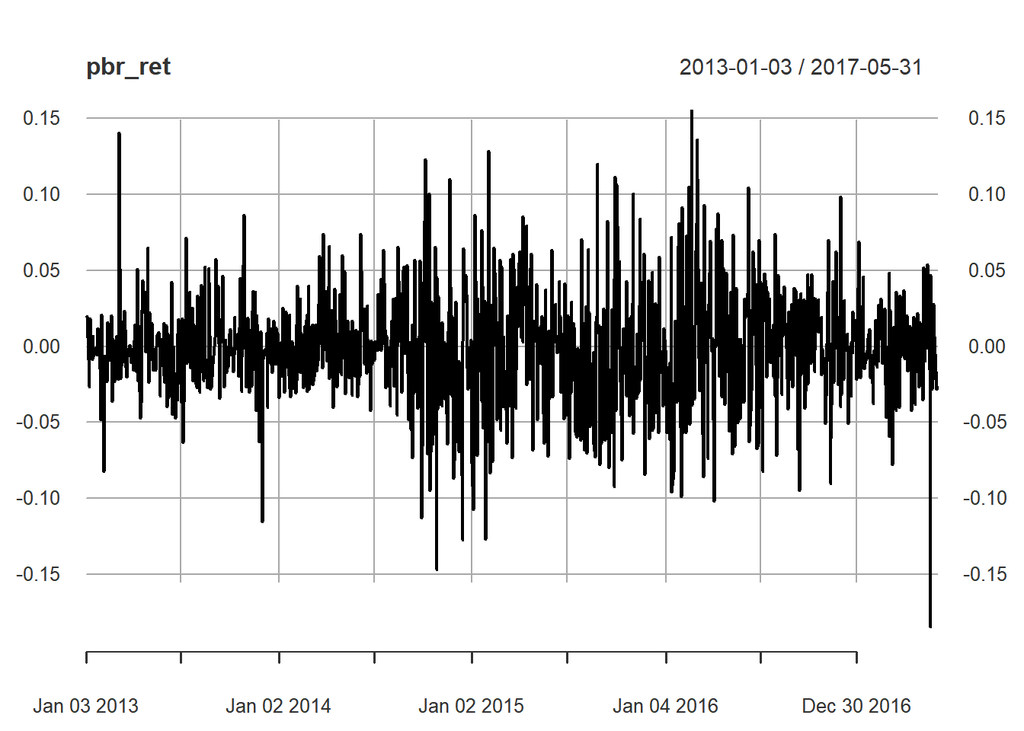

```r
pbr_ret <- diff(log(pbr[,6]))
pbr_ret <- pbr_ret[-1,]
plot(pbr_ret)
```

```r
# Basdaq series (USD)
spy <- getSymbols("SPY",
                  src = "yahoo",
                  from = "2013-01-01",
                  to = "2017-06-01",
                  auto.assign = FALSE)
summary(spy)
```

```
##      Index               SPY.Open        SPY.High        SPY.Low
##  Min.   :2013-01-02   Min.   :145.1   Min.   :145.9   Min.   :144.7
##  1st Qu.:2014-02-08   1st Qu.:183.6   1st Qu.:184.2   1st Qu.:182.7
##  Median :2015-03-18   Median :201.4   Median :202.3   Median :200.1
##  Mean   :2015-03-17   Mean   :197.1   Mean   :197.9   Mean   :196.2
##  3rd Qu.:2016-04-23   3rd Qu.:210.5   3rd Qu.:211.3   3rd Qu.:209.7
##  Max.   :2017-05-31   Max.   :241.8   Max.   :242.1   Max.   :241.4
##    SPY.Close       SPY.Volume         SPY.Adjusted
##  Min.   :145.6   Min.   : 35201900   Min.   :126.1
##  1st Qu.:183.7   1st Qu.: 77646050   1st Qu.:162.5
##  Median :201.4   Median : 99726000   Median :182.3
##  Mean   :197.1   Mean   :111298052   Mean   :178.6
##  3rd Qu.:210.6   3rd Qu.:132157950   3rd Qu.:192.2
##  Max.   :241.8   Max.   :507244300   Max.   :228.1
```

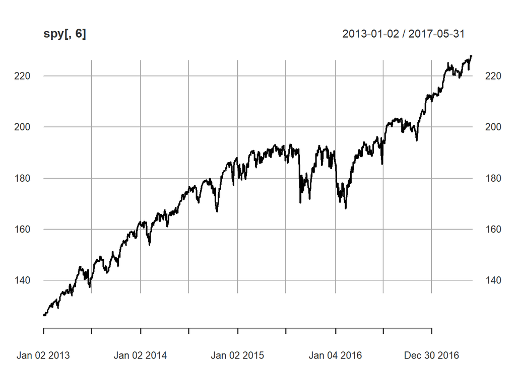

```r
plot(spy[,6])
```

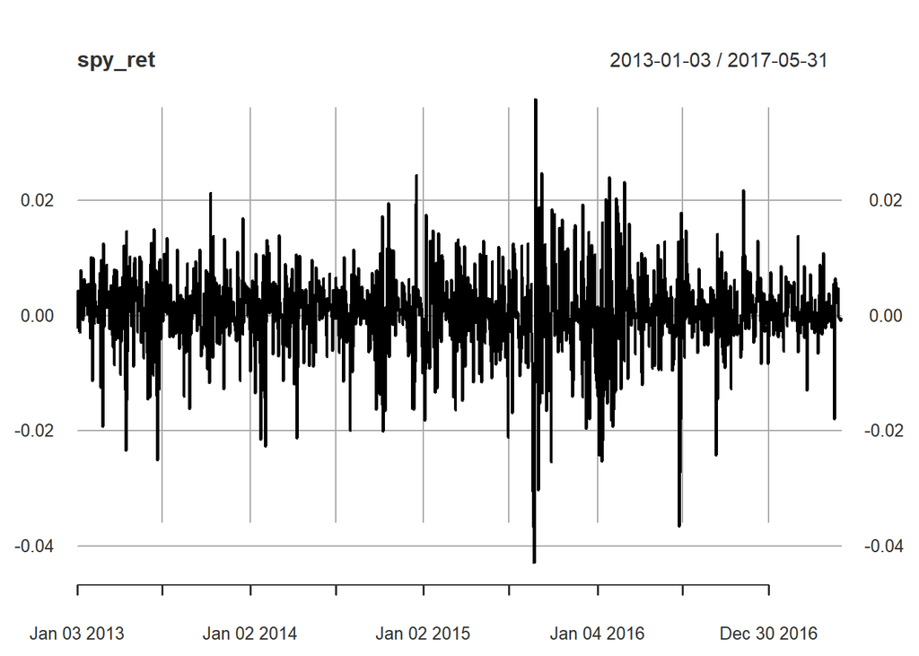

```r
spy_ret <- diff(log(spy[,6]))
spy_ret <- spy_ret[-1,]
plot(spy_ret)
```

```r
# Merging returns series

port_ret <- cbind(pbr_ret,spy_ret)
```

### 2.2.2 Point estimates

Point estimate for the **mean return**, $\hat{\mu}_t$:

```r
# Point estimatores
mu.est <- colMeans(port_ret)
mu.est
```

```
##  PBR.Adjusted  SPY.Adjusted
## -0.0007124013  0.0005296941
```

Point estimate for the **covariance matrix of returns**, $\hat{\Sigma}_t$:

```r
sigma.est <- cov(port_ret)
sigma.est
```

```
##              PBR.Adjusted SPY.Adjusted
## PBR.Adjusted 0.0013772819 1.211004e-04
## SPY.Adjusted 0.0001211004 6.061847e-05
```

### 2.2.3 Allocation strategy

```r
if(!require("quadprog")){install.packages("quadprog")}
library("quadprog")
```

```r
symbols = c('SPY','IWM','EFA','EEM','AGG','IYR','GLD')
symbol.names = c('S&P 500','Russell 2000','Europe, Australasia, Far East developed', 'Emerging Markets','Agg bond','REIT','Gold')
getSymbols(symbols, from = '2003-01-01', auto.assign = TRUE)
```

```
## pausing 1 second between requests for more than 5 symbols
## pausing 1 second between requests for more than 5 symbols
## pausing 1 second between requests for more than 5 symbols
```

```
## [1] "SPY" "IWM" "EFA" "EEM" "AGG" "IYR" "GLD"
```

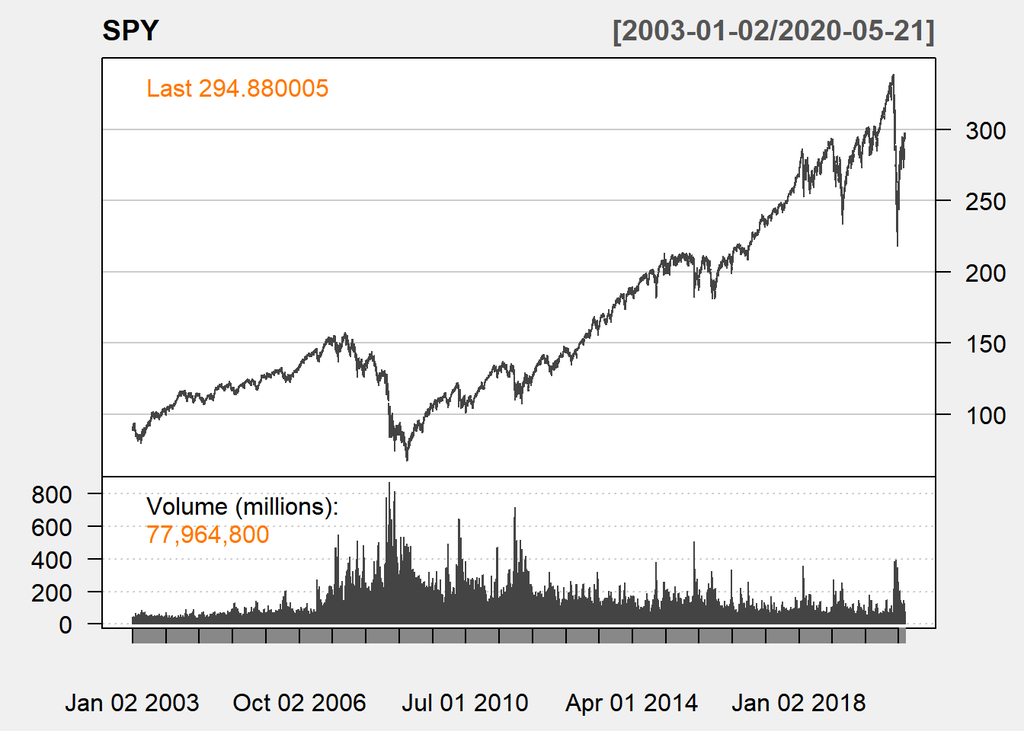

```r
candleChart(SPY,theme='white', type='candles')
```

### 2.2.4 Nominal and real returns

```r
realreturns = apply(freal, 2, mean)
realreturnspct = realreturns*100
realreturnspct
```

```
##    stocks     bills     bonds      gold
## 8.1255600 0.5107407 2.0921865 1.7287079
```

### 2.2.5 Real volatility (covariance)

```r
realsds = apply(freal, 2, sd)
realsdspct = realsds*100
realsdspct
```

```
##    stocks     bills     bonds      gold
## 20.556871  4.116415  9.095301 15.834720
```

### 2.2.6 Optimal solution

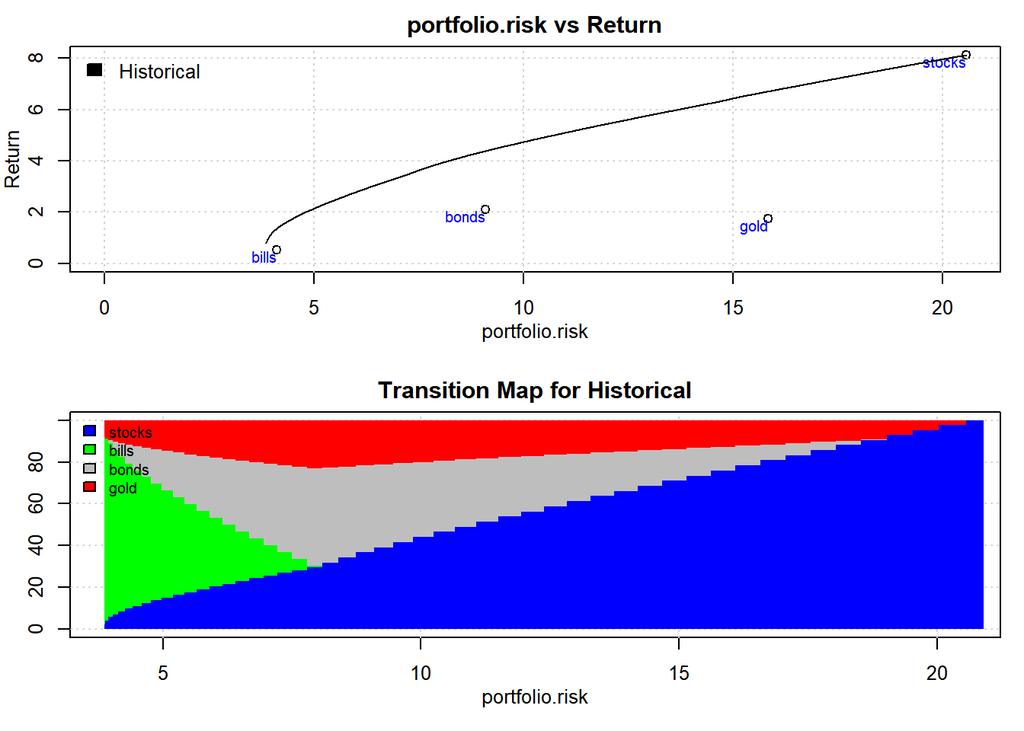

```r
layout( matrix(1:2, nrow = 2) )
plot.ef(ia, list(ef.risk), portfolio.risk, T, T)
```